# FigureYa155ATAC

小丫画图出品

2019-12-22

欢迎关注“小丫画图”公众号，回复“小白”，看小视频，实现点鼠标跑代码。

小丫微信: epigenomics E-mail: figureya@126.com

作者：赵龙，中科院遗传所在读博士

擅长：ChIP-seq，MNase-seq，ATAC-seq，HiC，ChIA-PET，GWAS分析，R语言。

兴趣：单细胞RNA-seq，ATAC-seq，机器学习相关。

小丫编辑校验

# 需求描述

复现染色质开放程度差异的热图。

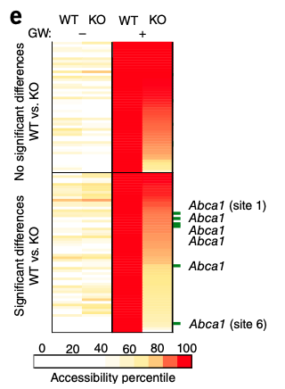

出自https://www.nature.com/articles/nm.4479

Figure 4 MeXis alters chromosome architecture at the Abca1 locus.

Top, genome-wide accessibility sites significantly induced by GW3965 in both WT and MeXis−/− macrophages.

Bottom, accessibility sites significantly induced by GW3965 only in WT macrophages. Significance was determined on the basis of a P value threshold of 0.05 using DESeq2 in the bioconductor statistical package.

**图的解读**

原文中图片d主要表示在有GW3965处理下，abca1基因上WT的染色质开放程度要高于KO。而作为对照，Tlr4 基因没有明显变化。另一方面，图e表示，在没有处理的条件下，野生型和突变体一系列基因没有染色质开放程度差异，但是在有处理的条件下，突变体的染色质开放程度要低于野生型。其中highlight了Abca1的几个peak的变化。

# 应用场景

用热图展示染色质开放程度差异，同样适用于ChIP-seq数据。

# 环境设置

安装要用到的软件：

- pfastq-dump，https://github.com/inutano/pfastq-dump
- fastqc，https://www.bioinformatics.babraham.ac.uk/projects/fastqc/
- bowtie2，https://sourceforge.net/projects/bowtie-bio/files/bowtie2/2.3.5.1/
- samtools，http://samtools.sourceforge.net/
- sambamba，http://lomereiter.github.io/sambamba/
- macs2，https://github.com/taoliu/MACS/wiki/Install-macs2
- deeptools，https://deeptools.readthedocs.io/en/develop/content/installation.html

安装R包

```r
options("repos"= c(CRAN="https://mirrors.tuna.tsinghua.edu.cn/CRAN/"))
options(BioC_mirror="http://mirrors.ustc.edu.cn/bioc/")
BiocManager::install("DESeq2")
BiocManager::install("ChIPseeker")
```

加载包

```r
library(dplyr)
library(DESeq2)
library(ChIPseeker)
library(GenomicFeatures)
```

```r
library(stringr)
library(ComplexHeatmap)
library(circlize)
library(RColorBrewer)
Sys.setenv(LANGUAGE = "en") #显示英文报错信息
options(stringsAsFactors = FALSE) #禁止chr转成factor
```

# 输入文件的准备

如果你已经获得`rawCount.txt`文件，就可以跳过这步，直接进入“开始画图”。

sra和bam文件已上传到百度云，链接：https://pan.baidu.com/s/1_iUX6rb1aZYRU42jeqtE4w，提取码：j2k1

## 下载参考基因组

从[ensembl](http://asia.ensembl.org/info/data/ftp/index.html)下载基因组DNA序列fa和注释gtf文件

## 下载sra数据

- SETP 1 在原文找到ID：Data availability. The source data used in the manuscript can be accessed using the following accession numbers: GSE98910 (RNA-seq), GSE97207 (ATAC-seq), GSE104027 (ChIP–seq), and GSE107977 (microarray).
- SETP 2 在GEO数据库中搜索GSE97207，进入页面https://www.ncbi.nlm.nih.gov/geo/query/acc.cgi?acc=GSE97207
- SETP 3 点击SRP102711，进入https://www.ncbi.nlm.nih.gov//sra/?term=SRP102711，点击右上角Send to——File_——Summary，会下载到`sra_result.csv`文件，里面有样本信息。
- SETP 4 继续点击右上角Send to——File_——Runinfo，会下载到`SraRunInfo.csv`文件，里面有下载链接`download_path`.

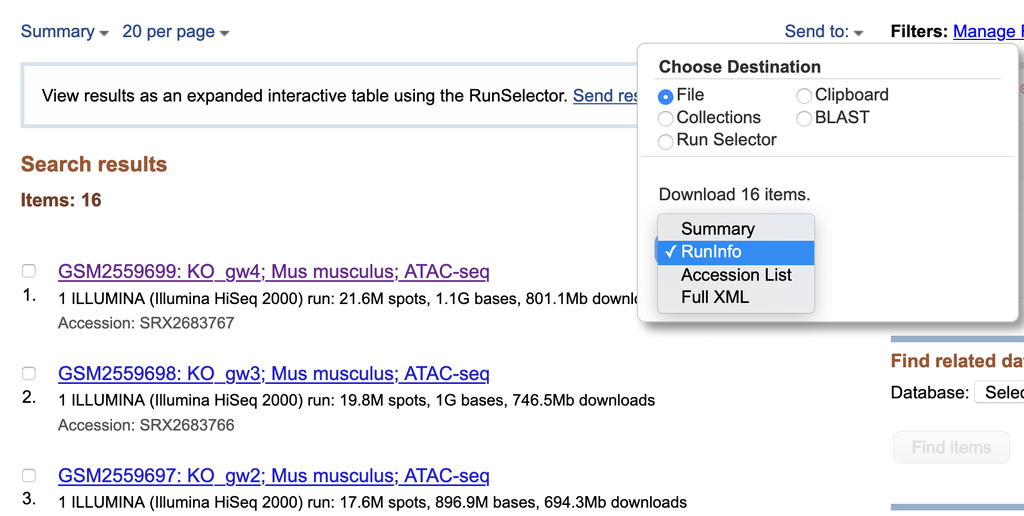

SETP 5 提取下载链接并下载SRR文件

```bash
#awk '{FS = ","; print $10}' SraRunInfo.csv > SRRurl.txt
#这里用wget，你可以尝试迅雷等工具
#wget -c -i SRRurl.txt
mkdir 0sra
mv SRR* 0sra
```

SETP 6 把sra数据转换成fastq数据

```bash
# pfastq-dump，并行更快，代替fastq-dump
for i in 0sra/*; do echo "pfastq-dump -t 10 --gzip -O ./ $i"; done > command.pfastq.sh
sh command.pfastq.sh
```

STEP 7 根据`sra_result.csv`和`SraRunInfo.csv`，手动整理成`samples.conf`文件。分为两列，第一列是SRRxxxx，第二列是对应的需要改成的样本名。

## 质控、alignment，bam文件转成bigwig文件用于下游分析

```bash
## 质控
fastqc -t 30 *.fastq.gz
#原文数据质量较好，都可用于下一步分析。

## Alignment 并且去掉duplication
#build index
bowtie-build mm9.fa MM9
#align
for i in *.fastq.gz; do x=${i/.fastq.gz/}; echo "bowtie2 -p 6 -x MM9 -U $i | samtools view -bS| samtools sort - | samtools rmdup -s - $x.bam"; done > command.bowtie.sh
sh command.bowtie.sh

# Sambamba，并行更快，代替samtools
for i in *.bam; do x=${i/.bam/}; echo "sambamba markdup -r -t 4 $i $x.rmdup.bam"; done > command.rmdup.sh
sh command.rmdup.sh

## bam转bigwiga,简单show一下开放程度
nohup samtools merge KO_GW.bam  SRR5388878.rmdup.bam SRR5388879.rmdup.bam SRR5388880.rmdup.bam SRR5388881.rmdup.bam &
nohup samtools merge WT_GW.bam SRR5388870.rmdup.bam SRR5388871.rmdup.bam SRR5388872.rmdup.bam SRR5388873.rmdup.bam &
samtools index KO_GW.bam ; samtools index WT_GW.bam
bamCoverage -bs 1 --effectiveGenomeSize 2620345972 --normalizeUsing RPKM -b KO_GW.bam -o KO_GW.bw -p 20
bamCoverage -bs 1 --effectiveGenomeSize 2620345972 --normalizeUsing RPKM -b WT_GW.bam -o WT_GW.bw -p 20

cat samples.conf | while read line; do all=($line);SRR=${all[0]};study=${all[1]};old=$SRR.rmdup.bam; new=$study.bam; mv $old $new; done
```

## washu brower 展示bigwig文件

用[washu epigenome browser](https://epigenomegateway.wustl.edu/browser/)查看bigwig文件。这里截图出来，确实能够重复出原文的趋势。

washu也是大多数文章中的可视化方法，可以输出svg或者pdf格式。对三维基因组的可视化也做得很好，强烈推荐。

[figure not shown]

[figure not shown]

## call peak

```bash
for i in *.bam; do x=${i/.bam/}; echo "macs2 callpeak --nomodel -t $i -q 0.01 -f BAM -g mm --keep-dup all --llocal 10000 -n $x 2> $x.macs2.log"; done > command.macs2.sh
sh command.macs2.sh
```

## intersect and merge peak file

有多次生物学重复，下面是不同生物学重复之间peak overlap的处理方法：

overlap的标准就是overlap的部分占两个生物学重复的50%以上。

```bash
echo -e "1\t2
1\t3
1\t4
2\t3
2\t4
3\t4" > paire.txt

for i in KO_DM KO_GW WT_DM WT_GW; do cat paire.txt | while read line; do all=($line); first=${all[0]}; second=${all[1]}; echo "bedtools intersect -wa -a $i\_$first\_peaks.narrowPeak -b KO_DM\_$second\_peaks.narrowPeak -f 0.5 -F 0.5 > $i.$first.$second.tmp.bed
bedtools intersect -wa -a KO_DM\_$second\_peaks.narrowPeak -b $i\_$first\_peaks.narrowPeak -f 0.5 -F 0.5 > $i.$second.$first.tmp.bed
cat $i.$first.$second.tmp.bed $i.$second.$first.tmp.bed | bedtools sort | bedtools merge -d -150 > $i.$first.$second.tmp_merge.bed"; done; done > command.sh

sed -i 's/\\_/_/g' command.sh
sh command.sh

for i in KO_DM KO_GW WT_DM WT_GW; do cat $i*.tmp_merge.bed | bedtools sort | bedtools merge -d -150 | awk '!x[$0]++' > $i.bed; done

rm -rf *.tmp.bed *.tmp_merge.bed

# 把所有的peak文件merge到一起，主要用于后面每个peak中read count数量的计算
cat *.bed |bedtools sort | bedtools merge -i - > allMerge.bed
```

## peak注释

peak注释到基因层面，主要用Y叔的ChIPseeker。

这里用gtf文件做了一个txdb注释文件，同样适用于bioconductor中没有txdb的物种。

除了生成txdb注释文件，还会输出一个bed文件，用于后面的进行reads的定量。

```r
# 生成txdb注释文件
TxDb.MM9 <- makeTxDbFromGFF("mm9.gtf", format="gtf", organism="Mus musculus")

peak <- readPeakFile("allMerge.bed",head=F)
peakAnn <- annotatePeak(peak, TxDb=TxDb.MM9, level="gene")
peakAnn <- as.data.frame(peakAnn)
write.table(peakAnn,"peakAnn.txt",sep="\t",quote=F,row.names=F)

peakSaf <- peakAnn[,c(12,1,2,3)]
peakSaf$Strand <- "."
colnames(peakSaf) <- c("GeneID","Chr","Start","End","Strand")
peakSaf$GeneID <- paste(peakSaf$GeneID,1:nrow(peakSaf),sep="_")
write.table(peakSaf,"peak.saf",sep="\t",quote=F,row.names=F)
```

## FeatureCount定量reads

```bash
featureCounts -a peak.saf -F SAF -T 20 -o rawCount.txt *.bam
```

# 开始画图

rawCount.txt，前面生成的。每行一个基因，前6列是基因位置信息，后面每列是一个样本的read count。可以类比成RNA-seq的read count进行差异分析。

先筛选显著差异基因，然后画图。

```r
data <- read.table("rawCount.txt",head=T)
rownames(data) <- data[,1]
data <- data[,-c(1:6)]
colnames(data) <- substring(colnames(data),1,7)

# 用DESeq2计算差异
sample <- data.frame(conditions=substring(colnames(data),1,5))
ddsFullCountTable <- DESeqDataSetFromMatrix(countData = data,colData = sample,  design= ~ conditions)
dds <- DESeq(ddsFullCountTable)
```

```r
rawcount <- as.data.frame(counts(dds, normalized=TRUE))

# WT_GW > WT_DM，并且KO_GW > KO_DM作为上面的heatmap
# WT_GW > WT_DM，但是KO_GW <= KO_DM作为下面的heatmap
contrast_WT_GW_WT_DM <- c("conditions","WT_GW","WT_DM")
res_WT_GW_WT_DM <- results(dds,contrast=contrast_WT_GW_WT_DM)
up1 <- rownames(subset(as.data.frame(res_WT_GW_WT_DM), as.data.frame(res_WT_GW_WT_DM)$log2FoldChange > 0 & as.data.frame(res_WT_GW_WT_DM)$padj <= 0.05))

contrast_KO_GW_KO_DM <- c("conditions", "KO_GW", "KO_DM")
res_KO_GW_KO_DM <- results(dds,contrast=contrast_KO_GW_KO_DM)
up2 <- rownames(subset(as.data.frame(res_KO_GW_KO_DM), as.data.frame(res_KO_GW_KO_DM)$log2FoldChange > 0 & as.data.frame(res_KO_GW_KO_DM)$padj <= 0.05))

top <- intersect(up1,up2)
bottom <- setdiff(up1,up2)
top_df <- rawcount[top,]
bottom_df <- rawcount[bottom,]

#处理成平均数
top_df_matrix <- matrix(c(rowMeans(top_df[,9:12]),rowMeans(top_df[,1:4]),rowMeans(top_df[,13:16]),rowMeans(top_df[,5:8])),ncol=4)
colnames(top_df_matrix) <- c("WT_DM","KO_DM","WT_GW","KO_GW")
rownames(top_df_matrix) <- rownames(top_df)

bottom_df_matrix <- matrix(c(rowMeans(bottom_df[,9:12]),rowMeans(bottom_df[,1:4]),rowMeans(bottom_df[,13:16]),rowMeans(bottom_df[,5:8])),ncol=4)
colnames(bottom_df_matrix) <- c("WT_DM","KO_DM","WT_GW","KO_GW")
rownames(bottom_df_matrix) <- rownames(bottom_df)

#计算percentage
top_perce <- top_df_matrix
for (i in 1:4){
    top_perce[,i] <- top_df_matrix[,i]/top_df_matrix[,3]*100
    }
bottom_perce <- bottom_df_matrix
for (i in 1:4){
        bottom_perce[,i] <- bottom_df_matrix[,i]/bottom_df_matrix[,3]*100
}

# 排序
ord_top <- order(top_perce[,3],top_perce[,4],decreasing=T)
ht1 <- top_perce[ord_top,]
ord_bottom <- order(bottom_perce[,3],bottom_perce[,4],decreasing=T)
ht2 <- bottom_perce[ord_bottom,]

# 注释mark的位点
locations <- which(str_match(rownames(ht2),"ENSMUST00000030010*")!="NA")
labels <- c("Abca 1 (site 1)","Abca 1 (site 2)","Abca 1 (site 3)")

# 颜色设置
# 这里作者玩了个小trick：小于50%的都是白色
col <- c(rep("white",5), brewer.pal(6,"YlOrRd"))
seq <- seq(0,100,10)

ha <- rowAnnotation(foo = anno_mark(at = locations, labels = labels))
a <- Heatmap(ht1,col = colorRamp2(seq,col),
    show_row_names=F,cluster_columns = FALSE,
    cluster_rows=F, show_column_names = F,
    name="")

b <- Heatmap(ht2,col = colorRamp2(seq,col),
    show_row_names=F,cluster_columns = FALSE,
    cluster_rows=F,show_column_names = T,
    right_annotation = ha, show_heatmap_legend =F)

pdf(file="heatmap.pdf",width=3,height=6)
a%v%b
dev.off()
```

[figure not shown]

heatmap

这里剩下位点有点少，原文在作比较的时候用的pvalue<=0.05,而不是用的矫正后的p值。如果按照原文的话，会得到多的基因。但是，还是没有原文说的6个位点Abca1。

一种猜测就是原文做了4次生物学重复，而作者可能在其中选择某几个重复去做，而不是全部，然后通过不断的尝试，选在最能证明观点的数据进行可视化。